# SOC-GA 2332 Intro to Stats Lab 12

12/8/2023

## Part 0: Logistics

- Assignment 4 due on Dec. 20th, 11:59pm

## Part 1: Matching

- For the following parts on causal inference, we will use the Early Childhood Longitudinal Study dataset. We will examine the effect of going to a Catholic school (`catholic = 1`), as opposed to a public school (`catholic = 0`), on students’ standardized math score (`c5r2mtsc_std`). The pre-treatment covariates are:
  - `race_white`: Is the student white (1) or not (0)?
  - `p5hmage`: Mother’s age
  - `w3income`: Family income
  - `p5numpla`: Number of places the student has lived for at least 4 months
  - `w3momed_hsb`: Is the mother’s education level high-school or below (1) or some college or more (0)?

```r
## import data
ecls <- read.csv("data/ecls.csv")

## covariates variable name vector
ecls_cov <- c('race_white', 'p5hmage', 'w3income', 'p5numpla', 'w3momed_hsb')
```

### Check if sample is balanced

- To check if the sample is balanced or not, we first examine the difference in means by treatment status for outcome variable and covariates.
- As we can see, the difference in mean for match score and for covariates are statistically significant.

```r
## check difference in mean outcomes by school type
ecls %>%
  group_by(catholic) %>%
  summarise(n_students = n(),
            mean_math = mean(c5r2mtsc_std),
            std_error_math = sd(c5r2mtsc_std) / sqrt(n_students)) %>%
  kbl("html") %>%
  kable_classic_2(full_width = F)
```

| catholic | n_students | mean_math | std_error_math |
| --- | --- | --- | --- |
| 0 | 9568 | -0.0305958 | 0.0103854 |
| 1 | 1510 | 0.1938682 | 0.0223528 |

```r
## two Sample t-test: (H0: mean math scores do not differ by school types)
with(ecls, t.test(c5r2mtsc_std ~ catholic))
```

```
##
##  Welch Two Sample t-test
##
## data:  c5r2mtsc_std by catholic
## t = -9.1069, df = 2214.5, p-value < 0.00000000000000022
## alternative hypothesis: true difference in means between group 0 and group 1 is not equal to 0
## 95 percent confidence interval:
##  -0.2727988 -0.1761292
## sample estimates:
## mean in group 0 mean in group 1
##     -0.03059583      0.19386817
```

```r
## check difference in means for pre-treatment covariates by school types
## summarise group means for covariates
ecls %>%
  group_by(catholic) %>%
  select(one_of(ecls_cov)) %>%
  summarise_all(funs(mean(., na.rm = T))) %>%
  kbl("html") %>%
  kable_classic_2(full_width = F)
```

| catholic | race_white | p5hmage | w3income | p5numpla | w3momed_hsb |
| --- | --- | --- | --- | --- | --- |
| 0 | 0.5561246 | 37.56097 | 54889.16 | 1.132669 | 0.4640918 |
| 1 | 0.7251656 | 39.57516 | 82074.30 | 1.092701 | 0.2272069 |

```r
## Two sample t-test for every covariate
## lapply: a build-in loop that apply the t-test function along the name vector
lapply(ecls_cov, function(v){
  t.test(ecls[, v] ~ ecls[, 'catholic'])
})
```

```
## [[1]]
##
##  Welch Two Sample t-test
##
## data:  ecls[, v] by ecls[, "catholic"]
## t = -13.453, df = 2143.3, p-value < 0.00000000000000022
## alternative hypothesis: true difference in means between group 0 and group 1 is not equal to 0
## 95 percent confidence interval:
##  -0.1936817 -0.1444003
## sample estimates:
## mean in group 0 mean in group 1
##       0.5561246       0.7251656
##
##
## [[2]]
##
##  Welch Two Sample t-test
##
## data:  ecls[, v] by ecls[, "catholic"]
## t = -12.665, df = 2186.9, p-value < 0.00000000000000022
## alternative hypothesis: true difference in means between group 0 and group 1 is not equal to 0
## 95 percent confidence interval:
##  -2.326071 -1.702317
## sample estimates:
## mean in group 0 mean in group 1
##        37.56097        39.57516
##
##
## [[3]]
##
##  Welch Two Sample t-test
##
## data:  ecls[, v] by ecls[, "catholic"]
## t = -20.25, df = 1825.1, p-value < 0.00000000000000022
## alternative hypothesis: true difference in means between group 0 and group 1 is not equal to 0
## 95 percent confidence interval:
##  -29818.10 -24552.18
## sample estimates:
## mean in group 0 mean in group 1
##        54889.16        82074.30
```

[output cut: 13 more lines]

```
##        1.132669        1.092701
##
##
## [[5]]
##
##  Welch Two Sample t-test
##
## data:  ecls[, v] by ecls[, "catholic"]
## t = 18.855, df = 2107.3, p-value < 0.00000000000000022
## alternative hypothesis: true difference in means between group 0 and group 1 is not equal to 0
## 95 percent confidence interval:
##  0.2122471 0.2615226
## sample estimates:
## mean in group 0 mean in group 1
##       0.4640918       0.2272069
```

### Choose and execute a matching algorithm

- To create a balanced sample from the original, unbalanced dataset, we need to choose and execute a matching algorithm in order to created a balanced dataset for estimate ATE. The package `MatchIt` estimates the propensity score in the background and then matches observations based on the method of your choice.
- In this example we use *nearest neighbor* matching, which matches units based on some measure of distance. The default and most common measure is the propensity score difference, which is the difference between the propensity scores of each treated and control unit.

```r
## MatchIt does not allow missing values, so we need to remove observations with NAs
ecls_nomiss <- ecls %>%
  select(c5r2mtsc_std, catholic, all_of(ecls_cov)) %>%
  na.omit()

## nearest neighbor matching (see documentation for different matching methods)
mod_match <- matchit(catholic ~ race_white + w3income + p5hmage + p5numpla + w3momed_hsb,
                     method = "nearest",
                     estimand = "ATT",
                     data = ecls_nomiss)
```

### Create matched dataset

- Using the `matchit` function, we obtained a `matchit` object (`mod_match`) that can be used to create a dataframe that contains only the matched observations.
  - Note that in our case, this final dataset is smaller than the original: it contains 2,704 observations, which contains 1,352 original treated units, and the other 1,352 control units that match the treated units one on one.
  - The estimated effect is therefore ATT.
  - The final dataset contains a variable called `distance`, which is the propensity score.
  - Matching ideally requires a common support in propensity.

```r
## to create a dataframe containing only the matched observations
dta_m <- match.data(mod_match)
```

### Examine covariates after matching

- After matching, it is useful to plot the mean of each covariate against the estimated propensity score, color-coded by treatment status. If matching is done well, the treatment and control groups will have (near) identical means of each covariate at each value of the propensity score.

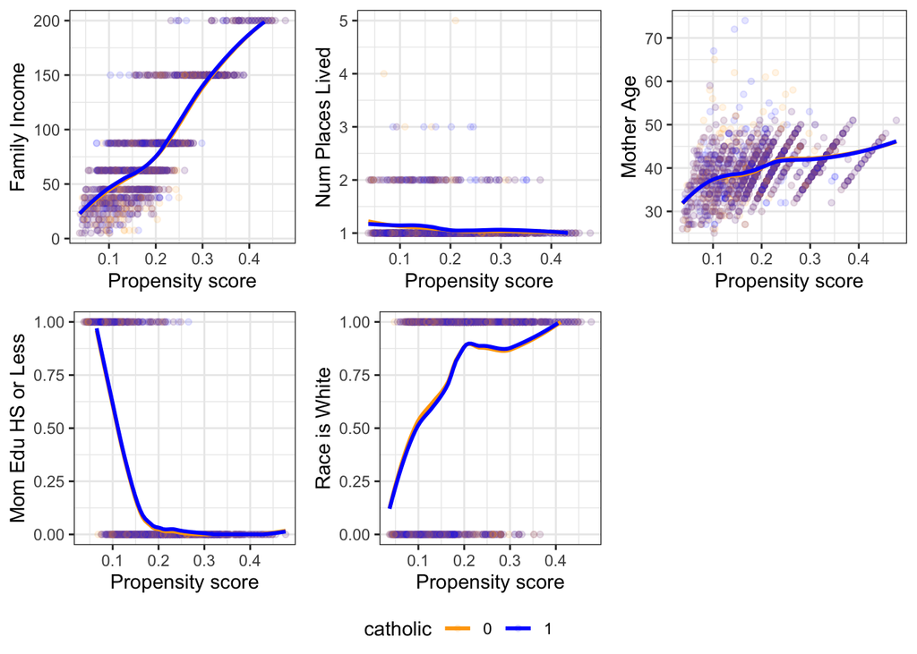

```r
## a plotting function that plots the distribution of propensity score of a given covariate
fn_bal <- function(dta, variable, yname) {
  dta$variable <- dta[, variable]
  if (variable == 'w3income') {
    dta$variable <- dta$variable / 10^3
    }
  dta$catholic <- as.factor(dta$catholic)
  support <- c(min(dta$variable), max(dta$variable))
  plot <- ggplot(dta, aes(x = distance, y = variable, color = catholic)) +
    geom_point(alpha = 0.1, size = 1.3) +
    geom_smooth(method = "loess", se = F) +
    scale_color_manual(values=c("orange", "blue")) +
    xlab("Propensity score") +
    ylab(yname) +
    theme_bw() +
    ylim(support)

  return(plot)
}

## plot and arrange the plots
ggarrange(
  fn_bal(dta_m, "w3income", "Family Income"),
  fn_bal(dta_m, "p5numpla", "Num Places Lived"),
  fn_bal(dta_m, "p5hmage", "Mother Age"),
  fn_bal(dta_m, "w3momed_hsb", "Mom Edu HS or Less"),
  fn_bal(dta_m, "race_white", "Race is White"),
  common.legend = T,
  legend = "bottom")
```

```r
## you can also check difference-in-means in matched data
dta_m %>%
  group_by(catholic) %>%
  select(one_of(ecls_cov)) %>%
  summarise_all(funs(mean)) %>%
  kbl("html") %>%
  kable_classic_2(full_width = F)
```

| catholic | race_white | p5hmage | w3income | p5numpla | w3momed_hsb |
| --- | --- | --- | --- | --- | --- |
| 0 | 0.7470414 | 39.5503 | 81403.99 | 1.076183 | 0.2152367 |
| 1 | 0.7411243 | 39.5932 | 82568.94 | 1.091716 | 0.2233728 |

```r
## two sample t-test
lapply(ecls_cov, function(v) {
  t.test(dta_m[, v] ~ dta_m$catholic)
})
```

```
## [[1]]
##
##  Welch Two Sample t-test
##
## data:  dta_m[, v] by dta_m$catholic
## t = 0.35243, df = 2701.8, p-value = 0.7245
## alternative hypothesis: true difference in means between group 0 and group 1 is not equal to 0
## 95 percent confidence interval:
##  -0.02700440  0.03883872
## sample estimates:
## mean in group 0 mean in group 1
##       0.7470414       0.7411243
##
##
## [[2]]
##
##  Welch Two Sample t-test
##
## data:  dta_m[, v] by dta_m$catholic
## t = -0.21331, df = 2702, p-value = 0.8311
## alternative hypothesis: true difference in means between group 0 and group 1 is not equal to 0
## 95 percent confidence interval:
##  -0.4372485  0.3514496
## sample estimates:
## mean in group 0 mean in group 1
##         39.5503         39.5932
##
##
## [[3]]
##
##  Welch Two Sample t-test
##
## data:  dta_m[, v] by dta_m$catholic
## t = -0.64787, df = 2701.9, p-value = 0.5171
## alternative hypothesis: true difference in means between group 0 and group 1 is not equal to 0
## 95 percent confidence interval:
##  -4690.731  2360.845
## sample estimates:
## mean in group 0 mean in group 1
##        81403.99        82568.94
```

[output cut: 13 more lines]

```
##        1.076183        1.091716
##
##
## [[5]]
##
##  Welch Two Sample t-test
##
## data:  dta_m[, v] by dta_m$catholic
## t = -0.51108, df = 2701.5, p-value = 0.6093
## alternative hypothesis: true difference in means between group 0 and group 1 is not equal to 0
## 95 percent confidence interval:
##  -0.03935185  0.02307966
## sample estimates:
## mean in group 0 mean in group 1
##       0.2152367       0.2233728
```

### Estimate Treatment Effects

- Using matched dataset, we can now estimate ATT using two different methods.
  - We can either use the results of a two sample t-test and calculate the difference in means
  - or regress mean math score on school types
    - Note that since we are using the matched dataset, the distribution of the covariates, in our case, are balanced in both the treatment and control group
    - Therefore, whether control variables are included or not in the linear model, in our case, would not affect the ATT estimate

```r
## 1. two sample t-test
with(dta_m, t.test(c5r2mtsc_std ~ catholic))
```

```
##
##  Welch Two Sample t-test
##
## data:  c5r2mtsc_std by catholic
## t = 4.5214, df = 2682.1, p-value = 0.000006411
## alternative hypothesis: true difference in means between group 0 and group 1 is not equal to 0
## 95 percent confidence interval:
##  0.08929508 0.22605937
## sample estimates:
## mean in group 0 mean in group 1
##       0.3673451       0.2096679
```

```r
## mean in group 0: 0.3673451
## mean in group 1: 0.2096679
## ATT = 0.2096679 - 0.3673451 = -0.1576772

## 2. OLS model
## no covariates
lm_treat1 <- lm(c5r2mtsc_std ~ catholic, data = dta_m)
## with covariates
lm_treat2 <- lm(c5r2mtsc_std ~ catholic + race_white + p5hmage +
                  I(w3income / 10^3) + p5numpla + w3momed_hsb, data = dta_m)
## display models
stargazer(lm_treat1, lm_treat2, type="text",
          star.char = c("+", "*", "**", "***"),
          star.cutoffs = c(0.1, 0.05, 0.01, 0.001))
```

```
##
## =====================================================================
##                                    Dependent variable:
##                     -------------------------------------------------
##                                       c5r2mtsc_std
##                               (1)                      (2)
## ---------------------------------------------------------------------
## catholic                   -0.158***                -0.157***
##                             (0.035)                  (0.033)
##
## race_white                                           0.334***
##                                                      (0.038)
##
## p5hmage                                              0.011***
##                                                      (0.003)
##
## I(w3income/103)                                      0.003***
##                                                      (0.0004)
##
## p5numpla                                              -0.045
##                                                      (0.055)
##
## w3momed_hsb                                         -0.304***
##                                                      (0.041)
##
## Constant                    0.367***                 -0.463**
##                             (0.025)                  (0.148)
##
## ---------------------------------------------------------------------
## Observations                 2,704                    2,704
## R2                           0.008                    0.109
## Adjusted R2                  0.007                    0.107
## Residual Std. Error    0.907 (df = 2702)        0.860 (df = 2697)
## F Statistic         20.443*** (df = 1; 2702) 55.146*** (df = 6; 2697)
## =====================================================================
## Note:                                     *p<0.1; **p<0.05; ***p<0.01
```

## Part 2: Propensity Score

- This part will demonstrate how to create propensity score
- Recall that propensity score is the probability of being treated given a set of pre-treatment covariates.
- In `R`, we can estimate propensity score given the covariates by fitting a logistic regression with the treatment status as the outcome and covariates as predictors.
  - We still leverage the strong ignorability assumption and correct specification assumption to derive an unbiased estimate of the true propensity score.

```r
## rescale income
ecls <- ecls %>% mutate(w3income_1k = w3income/1000)

## fit a logistic regress to generate propensity score using covariates
m_ps <- glm(catholic ~ race_white + w3income_1k + p5hmage + p5numpla + w3momed_hsb,
            family = binomial(), data = ecls)
summary(m_ps)
```

```
##
## Call:
## glm(formula = catholic ~ race_white + w3income_1k + p5hmage +
##     p5numpla + w3momed_hsb, family = binomial(), data = ecls)
##
## Coefficients:
##               Estimate Std. Error z value             Pr(>|z|)
## (Intercept) -3.2125519  0.2379826 -13.499 < 0.0000000000000002 ***
## race_white   0.3145014  0.0700895   4.487        0.00000721848 ***
## w3income_1k  0.0073038  0.0006495  11.245 < 0.0000000000000002 ***
## p5hmage      0.0292168  0.0050771   5.755        0.00000000869 ***
## p5numpla    -0.1439392  0.0912255  -1.578                0.115
## w3momed_hsb -0.6935868  0.0743207  -9.332 < 0.0000000000000002 ***
## ---
## Signif. codes:  0 '***' 0.001 '**' 0.01 '*' 0.05 '.' 0.1 ' ' 1
##
## (Dispersion parameter for binomial family taken to be 1)
##
##     Null deviance: 7701.3  on 9266  degrees of freedom
## Residual deviance: 7168.8  on 9261  degrees of freedom
##   (1811 observations deleted due to missingness)
## AIC: 7180.8
##
## Number of Fisher Scoring iterations: 5
```

```r
## use above model to generate propensity
## (the probability of being treated given a set of pre-treatment covariates)
prs_df <- data.frame(pr_score = predict(m_ps, type = "response"),
                     catholic = m_ps$model$catholic)

head(prs_df) %>%
  kbl("html") %>%
  kable_classic_2(full_width = F)
```

|  | pr_score | catholic |
| --- | --- | --- |
| 1 | 0.2292928 | 0 |
| 2 | 0.1801360 | 0 |
| 4 | 0.2092957 | 0 |
| 5 | 0.2154022 | 1 |
| 6 | 0.3604931 | 0 |
| 7 | 0.1080608 | 0 |

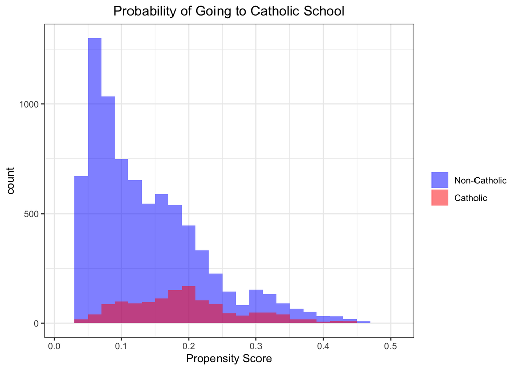

```r
## check the region of common support
## in every unit in the treatment, is there a control unit?
prs_df %>%
  ggplot(aes(x = pr_score, fill = as.factor(catholic))) +
  geom_histogram(binwidth = 0.02, alpha = 0.5, position="identity") +
  ggtitle("Probability of Going to Catholic School") +
  xlab("Propensity Score") +
  theme_bw() +
  theme(plot.title = element_text(hjust = 0.5)) +
  scale_fill_manual(name=" ",
                    values = c("blue", "red"),
                    labels = c("Non-Catholic", "Catholic"))
```

## Part 3: Inverse probability weighting

- Use propensity scores to weight units based on their probabilities of being treated.
- There are several options that measure different quantities of interest
  - `IPW` measures ATE. $weight(w_1,w_0) = (\frac{1}{e(x)},\frac{1}{1-e(x)})$
    - The core of `IPW` is to create a weighted treatment group and a weighted control group whose covariates’ distribution resembles the distribution of the whole sample
  - `treated` measures ATT. $weight(w_1,w_0) = (1,\frac{e(x)}{1-e(x)})$
    - The core of `treated` is to create only a weighted control group whose covariates’ distribution resembles the distribution of the unweighted treatment group
  - `overlap` measures ATO. $weight(w_1,w_0) = (1 - e(x),e(x))$
    - The core of `overlap` is to give more weights to the observations near the center of the propensity, or the units under “equipoise”
- You may check [this site](https://stats.stackexchange.com/questions/529602/which-one-of-these-methods-ate-att-ato-overlap-should-be-used-to-evaluate-a) for more detailed explanations

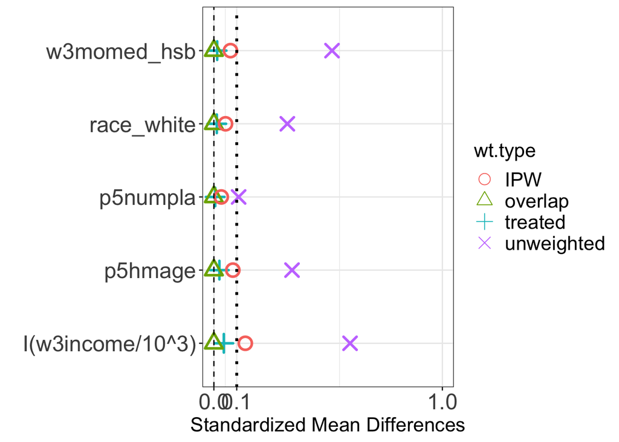

```r
## matching algorithm
ps.formula <- catholic ~ race_white + p5hmage +
                  I(w3income / 10^3) + p5numpla + w3momed_hsb

bal.ipw <- SumStat(ps.formula = ps.formula, zname ="catholic",
weight = c("treated", "overlap", "IPW"), data = ecls_nomiss)

# check balance by weight type
plot(bal.ipw)
```

- Estimate ATT, ATO, and ATE:

```r
## average treatment effect among the treated population
att <- PSweight(ps.formula = ps.formula, yname = "c5r2mtsc_std", data = ecls_nomiss, family = "gaussian",
weight = "treated")

## average treatment effect among the overlap population
ato <- PSweight(ps.formula = ps.formula, yname = "c5r2mtsc_std", data = ecls_nomiss, family = "gaussian",
weight = "overlap")

## average treatment effect using IPW
ate <- PSweight(ps.formula = ps.formula, yname = "c5r2mtsc_std", data = ecls_nomiss, family = "gaussian",
weight = "IPW")

## check results
summary(att)
```

```
##
## Closed-form inference:
##
## Original group value:  0, 1
## Treatment group value:  1
##
## Contrast:
##             0 1
## Contrast 1 -1 1
##
##            Estimate Std.Error      lwr       upr    Pr(>|z|)
## Contrast 1 -0.12161   0.02595 -0.17247 -0.070751 0.000002781 ***
## ---
## Signif. codes:  0 '***' 0.001 '**' 0.01 '*' 0.05 '.' 0.1 ' ' 1
```

```r
summary(ato)
```

```
##
## Closed-form inference:
##
## Original group value:  0, 1
##
## Contrast:
##             0 1
## Contrast 1 -1 1
##
##             Estimate Std.Error       lwr      upr  Pr(>|z|)
## Contrast 1 -0.098938  0.025500 -0.148916 -0.04896 0.0001045 ***
## ---
## Signif. codes:  0 '***' 0.001 '**' 0.01 '*' 0.05 '.' 0.1 ' ' 1
```

```r
summary(ate)
```

```
##
## Closed-form inference:
##
## Original group value:  0, 1
##
## Contrast:
##             0 1
## Contrast 1 -1 1
##
##              Estimate  Std.Error        lwr      upr Pr(>|z|)
## Contrast 1 -0.0087096  0.0290430 -0.0656329 0.048214   0.7643
```

- Why is ATE and ATT different?

## Part 4: Instrumental Variables

- We’ll look at an example from [Causal Inference: The Mixtape](https://mixtape.scunning.com) by Scott Cunningham
- In this example we use data from NLS Young Men Cohort of the National Longitudinal Survey to consider the returns to schooling in terms of income. Card (1995) wants to estimate:

$$Y_{i} = \alpha + \beta_{1}S_{i} + \beta_{2}X_i + \epsilon_i$$

- where $Y$ is log earnings, $S$ is years of schooling, $X$ is a matrix of observed covariates and $epsilon$ is an error term containing unobserved endogenous covariates, for example, ability. Ability, we might expect, is correlated with income as well as years of schooling. Therefore schooling is biased.
- Card (1995) proposes an instrumental variables strategy whereby he will instrument for schooling with the college-in-the-county dummy variable. The assumption is that if there a nearby 4-year college it will increase the likelihood of going to college.

### Estimating causal effects using IV designs

- One of the most common and intuitive estimators is two-stage least squares, with the instrument denoted as $Z_i$
- We estimate the first-stage (Effect of college-in-county on years of schooling):

$$S_{i}=\gamma+\rho Z_{i}+\eta X_i +u_{i}$$
* And plug the fitted values into the second-stage regression:

$$Y_{i} = \alpha^{iv} + \beta_1^{iv} \hat{S}_{i} + \beta_2^{iv}X_i + v_{i}$$
* This can be done manually in R by regressing with the predicted values, or using the `ivreg` function.

```r
## function to read the data from github
read_data <- function(df)
{
  full_path <- paste("https://raw.github.com/scunning1975/mixtape/master/",
                     df, sep = "")
  df <- read_dta(full_path)
  return(df)
}

## read data
card <- read_data("card.dta")

## define variable
## Endo = endogenous variable, Exo = exogenous variable, Inst = Instrument
attach(card)
Endo_educ <- educ
Exo_ <- cbind(exper, black, south, married, smsa)
Inst <- nearc4

## OLS
ols_reg <- lm(lwage ~ Endo_educ + Exo_)

## 2SLS
iv_reg <- ivreg(lwage ~ Endo_educ + Exo_ | Exo_ + Inst)

## how coef estimates
stargazer(ols_reg, iv_reg, type="text",
          star.char = c("+", "*", "**", "***"),
          star.cutoffs = c(0.1, 0.05, 0.01, 0.001))
```

```
##
## ======================================================================
##                                          Dependent variable:
##                                 --------------------------------------
##                                                 lwage
##                                            OLS            instrumental
##                                                             variable
##                                            (1)                (2)
## ----------------------------------------------------------------------
## Endo_educ                               0.071***             0.124*
##                                          (0.003)            (0.050)
##
## Exo_exper                               0.034***            0.056**
##                                          (0.002)            (0.020)
##
## Exo_black                               -0.166***           -0.116*
##                                          (0.018)            (0.051)
##
## Exo_south                               -0.132***          -0.113***
##                                          (0.015)            (0.023)
##
## Exo_married                             -0.036***          -0.032***
##                                          (0.003)            (0.005)
##
## Exo_smsa                                0.176***            0.148***
##                                          (0.015)            (0.031)
##
## Constant                                5.063***            4.162***
##                                          (0.064)            (0.850)
##
## ----------------------------------------------------------------------
## Observations                              3,003              3,003
## R2                                        0.305              0.251
## Adjusted R2                               0.304              0.250
## Residual Std. Error (df = 2996)           0.370              0.384
## F Statistic                     219.153*** (df = 6; 2996)
## ======================================================================
## Note:                                      *p<0.1; **p<0.05; ***p<0.01
```

- Recall that IV estimates are **LATE**
  - What can we infer about returns to schooling for compliers vs. always takers from the difference between the OLS estimate and the 2SLS estimate?

### Three IV design examples

- The effect of participating in war on long-term wage, using **lottery number as IV**:  
  [Lifetime Earnings and the Vietnam Era Draft Lottery: Evidence from Social Security Administrative Records](https://www.jstor.org/stable/2006669?seq=1#metadata_info_tab_contents), by Joshua D. Angrist, 1990, American Economic Review
- The effect of religious reform on literacy (human capital), using **distance to the religous reform center as IV**:  
  [Was Weber Wrong? A Human Capital Theory of Protestant Economic History](https://academic.oup.com/qje/article/124/2/531/1905076), by Sascha O. Becker and Ludger Woessmann, 2009, Quarterly Journal of Economics
- The effect of crime on student test scores, using **federal grants for increased policing**: [Crime and Inequality in Academic Achievement Across School Districts in the United States](https://read.dukeupress.edu/demography/article/57/1/123/168077), by Gerard Torrats-Espinosa, 2020, Demography